# Exploring Social Metacognition - Grid Repetition comparison

Matt Jaquiery (matt.jaquiery@psy.ox.ac.uk)

December 2018  
[Script run 2019-01-18 15:36:38]

# Descriptives

## Introduction

Participants performed a perceptual discrimination task in which they had to identify which of two boxes contained the most dots. Stimuli were presented for a brief time.

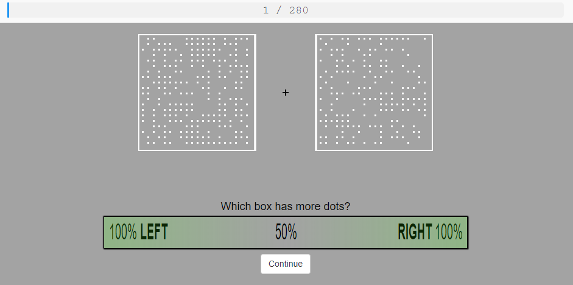

The Dot Task

## Load data

```
## Loaded data from G:\Documents\University\Google Drive\Temp\data\processed
```

```
## Generated utility variables
```

## Metadata

Responses (*N* = 18) were collected between 2019-01-18 03:51:04 and 2019-01-18 15:04:26.

Demographic data are not collected and therefore not analysed. Participants must be over 18 years old to use the Prolific recruitment platform.

# Exclusions

We exclude participants for:

- Proportion of correct initial judgements must be (.65 < cor1/n < .85) (*N* = 0)
- Having fewer than 3 confidence categories (*N* = 1)
- Having fewer than 5% of trials in each confidence category (*N* = 0)
- There being more data collected than specified in pre-registration (*N* = 0)

*NB: **practice trials are included** in this since they are used in part for determining confidence calibration*

The number of participants analysed after exclusions (total *N* = 1) have taken place is 17.

# Comparisons

## Type 1 performance

Participants’ performance was held at 71% by design. Participants’ mean percentage correct was *M* = .77 [0.75, 0.79].

Type 1 performance should not differ as a function of repetition. This is checked by comparing the performance on the first appearance of repeated trials against performance on the repetitions.

[1] “BF = 4.95; *M*|novel = 0.75 [0.73, 0.77], *M*|repeat = 0.79 [0.77, 0.82]”

If there are differences, these may be due to:

- (implicit) memory effects
- a tendency for repeated trials to be easier due to the trimming process

Some trials have their grids switch side when repeated. Insofar as there is a difference in the original and repeated presentations, this difference should be attenuated by switching sides. This is tested by calculating a delta value for each repetition (1 = rep correct, original wrong; 0 = same accuracy; -1 = rep wrong, original correct), and testing the mean deltas by swapped status.

[1] “BF = 0.63; *M*|same = 0.06 [0.02, 0.09], *M*|swapped = 0.03 [-0.02, 0.07]”

## Type 2 performance

Type 2 (metacognitive) performance is characterised using Type 2 ROC. The mean ROC for all participants is tabulated below:

| conf | isRep | pCorrect |
| --- | --- | --- |
| (0,8.33] | FALSE | .62 |
| (8.33,16.7] | FALSE | .79 |
| (16.7,25] | FALSE | .83 |
| (25,33.3] | FALSE | .79 |
| (33.3,41.7] | FALSE | .86 |
| (41.7,50] | FALSE | .85 |
| (0,8.33] | TRUE | .57 |
| (8.33,16.7] | TRUE | .69 |
| (16.7,25] | TRUE | .79 |
| (25,33.3] | TRUE | .74 |
| (33.3,41.7] | TRUE | .75 |
| (41.7,50] | TRUE | .84 |

Participants’ ROC curves:

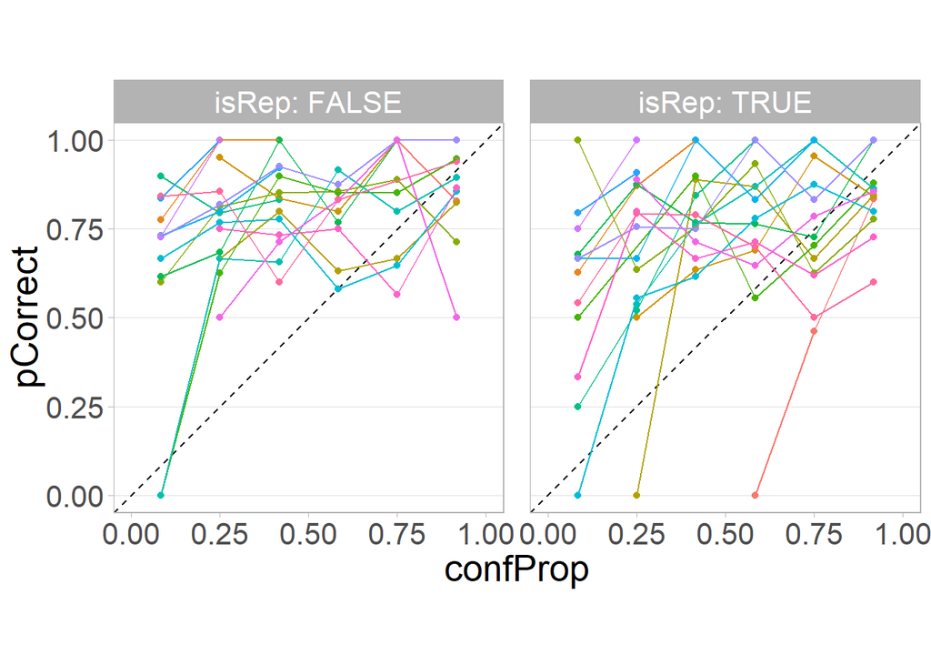

# Exploration

## Recognition test

Participants are given 5 grids and asked to select those which they recognise from the experiment. One of the grids comes from the previous block (‘repeat’), and one is from the previous block but with the left and right grids switched (‘swapped’). We examine the relative picking frequencies for each of these grids compared to novel grids (‘new’). This is exploratory because it cannot be guaranteed that novel grids aren’t swaps of earlier grids, or how many times repeats have been seen before (1 or 2).

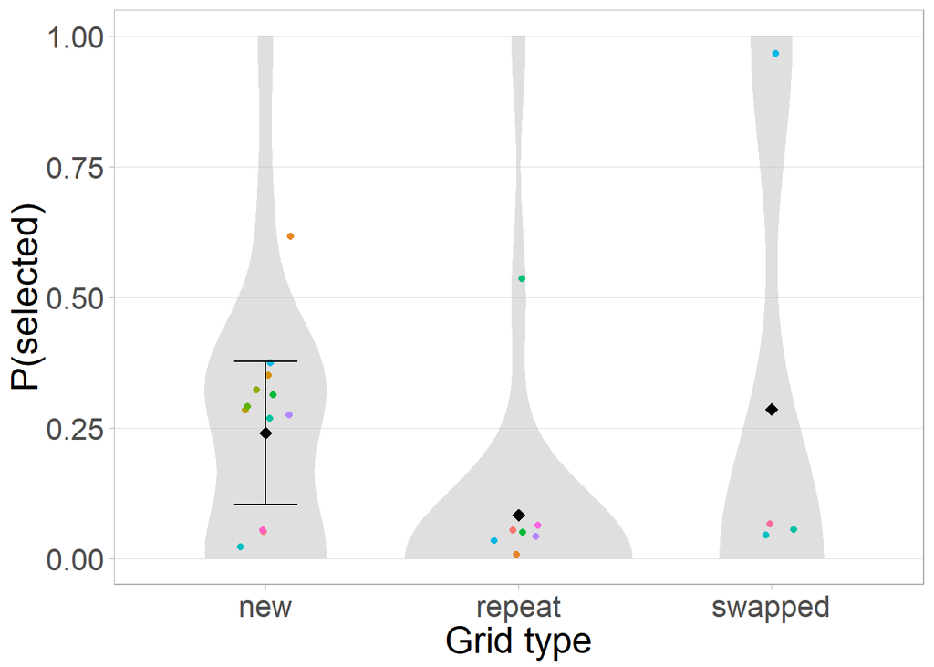

Overall, participants selected 1 responses on each quiz.

# Credits

## Acknowledgements

Thanks as always to Nick Yeung and the other folks at the [ACC Lab](https://www.psy.ox.ac.uk/research/attention-cognitive-control-lab).

## R Packages

| Package | Citations |
| --- | --- |
| base | R Core Team (2018). R: A language and environment for statistical computing. R Foundation for Statistical Computing, Vienna, Austria. URL https://www.R-project.org/. |
| Rcpp | Dirk Eddelbuettel and Romain Francois (2011). Rcpp: Seamless R and C++ Integration. Journal of Statistical Software, 40(8), 1-18. URL http://www.jstatsoft.org/v40/i08/. Eddelbuettel, Dirk (2013) Seaml… |
| prettyMD | Matt Jaquiery (2018). prettyMD: Format Test Outputs with Markdown. R package version 0.1.0. |
| scoring | Merkle, E. C. & Steyvers, M. (2013). Choosing a strictly proper scoring rule. Decision Analysis, 10, 292-304. |
| Hmisc | Frank E Harrell Jr, with contributions from Charles Dupont and many others. (2018). Hmisc: Harrell Miscellaneous. R package version 4.1-1. https://CRAN.R-project.org/package=Hmisc |
| Formula | Achim Zeileis, Yves Croissant (2010). Extended Model Formulas in R: Multiple Parts and Multiple Responses. Journal of Statistical Software 34(1), 1-13. doi:10.18637/jss.v034.i01 |
| survival |  |
| lattice | Sarkar, Deepayan (2008) Lattice: Multivariate Data Visualization with R. Springer, New York. ISBN 978-0-387-75968-5 |
| knitr | Yihui Xie (2018). knitr: A General-Purpose Package for Dynamic Report Generation in R. R package version 1.20. Yihui Xie (2015) Dynamic Documents with R and knitr. 2nd edition. Chapman and Hall/CRC. I… |
| ez | Michael A. Lawrence (2016). ez: Easy Analysis and Visualization of Factorial Experiments. R package version 4.4-0. https://CRAN.R-project.org/package=ez |
| lsr | Navarro, D. J. (2015) Learning statistics with R: A tutorial for psychology students and other beginners. (Version 0.5) University of Adelaide. Adelaide, Australia |
| lme4 | Douglas Bates, Martin Maechler, Ben Bolker, Steve Walker (2015). Fitting Linear Mixed-Effects Models Using lme4. Journal of Statistical Software, 67(1), 1-48. doi:10.18637/jss.v067.i01. |
| ggridges | Claus O. Wilke (2018). ggridges: Ridgeline Plots in ‘ggplot2’. R package version 0.5.1. https://CRAN.R-project.org/package=ggridges |
| forcats | Hadley Wickham (2018). forcats: Tools for Working with Categorical Variables (Factors). R package version 0.3.0. https://CRAN.R-project.org/package=forcats |
| stringr | Hadley Wickham (2018). stringr: Simple, Consistent Wrappers for Common String Operations. R package version 1.3.1. https://CRAN.R-project.org/package=stringr |
| dplyr | Hadley Wickham, Romain François, Lionel Henry and Kirill Müller (2018). dplyr: A Grammar of Data Manipulation. R package version 0.7.6. https://CRAN.R-project.org/package=dplyr |
| purrr | Lionel Henry and Hadley Wickham (2018). purrr: Functional Programming Tools. R package version 0.2.5. https://CRAN.R-project.org/package=purrr |
| readr | Hadley Wickham, Jim Hester and Romain Francois (2017). readr: Read Rectangular Text Data. R package version 1.1.1. https://CRAN.R-project.org/package=readr |
| tidyr | Hadley Wickham and Lionel Henry (2018). tidyr: Easily Tidy Data with ‘spread()’ and ‘gather()’ Functions. R package version 0.8.1. https://CRAN.R-project.org/package=tidyr |
| tibble | Kirill Müller and Hadley Wickham (2018). tibble: Simple Data Frames. R package version 1.4.2. https://CRAN.R-project.org/package=tibble |
| ggplot2 | H. Wickham. ggplot2: Elegant Graphics for Data Analysis. Springer-Verlag New York, 2016. |
| tidyverse | Hadley Wickham (2017). tidyverse: Easily Install and Load the ‘Tidyverse’. R package version 1.2.1. https://CRAN.R-project.org/package=tidyverse |
| BayesFactor | Richard D. Morey and Jeffrey N. Rouder (2018). BayesFactor: Computation of Bayes Factors for Common Designs. R package version 0.9.12-4.2. https://CRAN.R-project.org/package=BayesFactor |
| Matrix | Douglas Bates and Martin Maechler (2018). Matrix: Sparse and Dense Matrix Classes and Methods. R package version 1.2-14. https://CRAN.R-project.org/package=Matrix |
| coda | Martyn Plummer, Nicky Best, Kate Cowles and Karen Vines (2006). CODA: Convergence Diagnosis and Output Analysis for MCMC, R News, vol 6, 7-11 |
| jsonlite | Jeroen Ooms (2014). The jsonlite Package: A Practical and Consistent Mapping Between JSON Data and R Objects. arXiv:1403.2805 [stat.CO] URL https://arxiv.org/abs/1403.2805. |

## Funding

Matt Jaquiery is funded by a studentship from the [Medical Research Council](https://mrc.ukri.org/) (reference 1943590) and the University of Oxford [Department of Experimental Psychology](https://www.psy.ox.ac.uk/) (reference 17/18_MSD_661552).